# Proyecto Malla de backup

Jhon Alejandro Ospina Romero

12/16/2021

## Contexto

El servicio de respaldos es uno de los servcios mas importantes en las organizaciónes en la actualidad, las empresas apuestan cada vez por más procesos y servicios digitales que se vuelven indispensables para la operacion de la organizacion por ello, las vulnerabilidades y problemas pueden surgir, de manera que las copias de seguridad para restaurar lo que necesitemos son una parte fundamental de los planes de contingencia de cualquier organizacion.

El software de resplados utilizado es IBM Spectrum Protect™ que proporciona una amplia protección de datos para servidores físicos, así como entornos virtuales y una diversa gama de aplicaciones aunque este es un portente sofware para resplados la falta de optimizacion y los encolamientos de tareas de respaldos por el uso de recursos es una problema recuerrente, pues a medida que pasa el tiempo los datos respaldados van creciendo cada dia mas. Uno de los desafios como administradores de respaldos es analizar los datos de los respaldos ejecutados y en base a ellos lograr optimizar la malla de resplados ya sea reorganizando las ventanas o disponiendo mas infraestructura.

El cliente seguros Bolivar ejecuta mas 16.000 mil respaldos al mes repaldando mas de 1 Peta bit de informacion cada mes, debido a esta cantidad de informacion y ejecuciones hace que hacer alguna clase de analisis sin las herramientas adecuadas sea dificil mantener una malla de backup estable. Actualemente se estan presentando encolamientos en distintas franjas horarias es urgente realizar un analisis sobre las ejecuciones de backup para tomar acciones y solventar el problemas actual.

## Descripción de campos y/o variables de sus df.

Tipos de variables estadísticas

Tenemos un total de 9 variables con las siguientes caracteristicas.

SCHEDULED_START Cuantitativa continua Programacion del respaldo

ACTUAL_START Cuantitativa continua Incio del respaldo

DOMAIN_NAME Cualitativa nominal Dominio al que pertenece.

SCHEDULE_NAME Cualitativa nominal Nombre del resplado.

NODE_NAME Cualitativa nominal Nombre del nodo de conexion

STATUS Cualitativa ordinal Estado final de respaldo.

RESULT Cuantitativa discreta Codigo de retorno.

REASON Cualitativa nominal Breve descripcion de la finalicion del respaldo.

COMPLETED Cuantitativa continua Fecha y hora de finalizacion del resplado.

## Nuevas Variables

Con el proposito de lograr identificar el tiempo de ejecucion de cada uno de los respaldos se restan dos variables **SCHEDULE START** y **COMPLETED**.

Tambien se modifico la varible **ACTUAL START** con el fin de logra graficar la cantidad de resplados por dia esto con el fin de lograr evaluar atraves de la grafica de barras que dias en especifico esta sobre poblada de ejecuciones de respaldos.

## Tratamiento de Datos.

Debido a la gran cantidad de backups es importante logra focalizarnos donde se vean la mayor cantidad de backup fallidos para esto debemos graficar unicamente los backups failed por Dominio asi sabremos que dominio analizar.

Para lograr vizualizar esto mucho mejor se aplicaran dos filtros importantes vamos a quitar todos los valores que contengas ARCH en la variable SCHEDULE NAME esto lo hacemmos por que son valores que no generan ningun valor para nosotros, ademas de esto vamos a excuir el estado completed de nuestra varible STATUS ya que necesitamos saber cual de nuestros dominios tiene mas fallas de backup.

[figure not shown]

```r
resumen_dt = resumen  %>% spread(STATUS, cantidad)
view(resumen_dt)
```

Otro de los casos particulares y que dificulto mucho el proyecto es el cambio de variable ya que despues de varias pruebas se logro cambiar el tipo de la variable SCHEDULE START y COMPLETED que inicialmente estaban en caracter y se requerian en tipo fecha.

Teniendo en cuenta que en el grafico anterior logramos identificar que el dominio que mas fallas acumula es PD_UNX, entonces vamos a crear un grafica de barras que nos permita ver el acumulado de fallas de backup y los backups completos, asi anializaremos si realmete nuestra hipotesis es cierta.

Lo primero que debemos analizar es ver si realmente hay diferencias entre las ejecuciones de respaldos en los dias de la semana, esto lo haremos mediante un grafico de barras que contara la cantidad de ejecucion por dias del mes de octubre.

```r
resumen = origen_de_datos %>% filter(`DOMAIN NAME` == "PD_UNX")


resumen_actual = resumen %>% group_by(ACTUAL,STATUS) %>%
  summarise(cantidad = n())
```

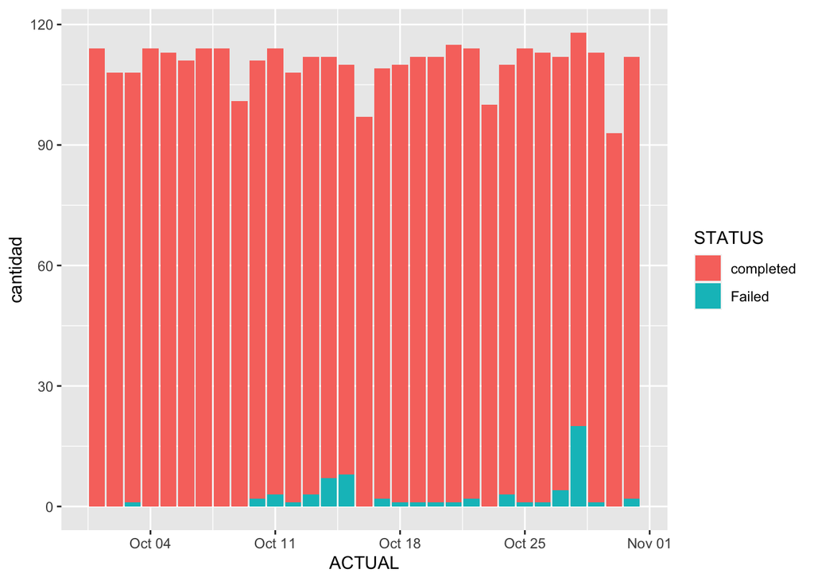

```r
ggplot(resumen_actual, aes(x = ACTUAL , y = cantidad, fill = STATUS)) + geom_bar(stat='identity')
```

Para lograr tratar estos datos especificamente las variables de **SCHEDULE START** y **COMPLETED** se tomaron cada una de las variables y se tranformo mediante la libreria lubridate que nos permite cambia las variables de tipo caracter a fecha, una vez fectuada la conversion se debio insertar los nuevos datos a nuestro df; esta conversion fue una de las dificiles de hacer ya que los caracteres debian coincidir con el tipo de fecha.

El desconcimiento del alcance de este lenguaje de programacion tambien fue una de las mayores dificultades ya que muchas de las ideas que se querian hacer no se lograron debido a que no sabia como hacerlo.